# Modelado y evaluación de los datos con RandomForest

## 100 variables

**Objetivo:** Construir, entrenar e interpretar modelos de aprendizaje automático utilizando los datos preparados, y evaluar su desempeño para seleccionar la mejor alternativa.

> Para cada subsección encontrarás una celda *Markdown* con instrucciones y una celda de *Python* para tu código.

```python
import numpy as np
import pandas as pd
from sklearn.model_selection import train_test_split
from sklearn.model_selection import train_test_split, StratifiedKFold, RandomizedSearchCV
from sklearn.metrics import accuracy_score, precision_score, recall_score, f1_score, roc_auc_score, confusion_matrix
import matplotlib.pyplot as plt
import seaborn as sns
from sklearn.ensemble import RandomForestClassifier
```

## 1. Selección del tipo de modelo

- Determinar si el problema es de clasificación, regresión o agrupamiento.
- Elegir los algoritmos adecuados según el tipo de problema y la naturaleza de los datos. Ejemplos:
  - Clasificación: Regresión logística, Árboles de decisión, Random Forest, SVM, Redes neuronales.
  - Regresión: Regresión lineal, Random Forest Regressor, XGBoost, Redes neuronales.
  - Agrupamiento: K-Means, DBSCAN, Hierarchical Clustering

```python
#Tipo de problema: Clasificación binaria (porque target=0 o target=1).
#Algoritmo: Random Forest.

modelo = RandomForestClassifier(
    random_state=42,
    n_jobs=-1
)
```

## 2. Separación de los conjuntos de datos

- Confirma la **separación train/test** (y opcionalmente *validation*).
- Asegura **reproducibilidad** (semilla aleatoria).

```python
train = pd.read_csv("train_100vars.csv")
test = pd.read_csv("test_100vars.csv")

train_ids = train["ID_code"]
test_ids = test["ID_code"]

X = train.drop(columns=["ID_code", "target"])
y = train["target"]

X_test = test.drop(columns=["ID_code"])

X_train, X_val, y_train, y_val = train_test_split(
    X,
    y,
    test_size=0.20,
    random_state=42,
    stratify=y
)

print("Dimensiones:")
print("X_train:", X_train.shape)
print("X_val:", X_val.shape)
print("X_test:", X_test.shape)

print("\nDistribución de clases en train:")
print(y_train.value_counts(normalize=True).round(4))

print("\nDistribución de clases en validation:")
print(y_val.value_counts(normalize=True).round(4))
```

```
Dimensiones:
X_train: (160000, 100)
X_val: (40000, 100)
X_test: (200000, 100)

Distribución de clases en train:
target
0    0.8995
1    0.1005
Name: proportion, dtype: float64

Distribución de clases en validation:
target
0    0.8995
1    0.1005
Name: proportion, dtype: float64
```

## 3. Entrenamiento del modelo

- Ajustar el modelo a los datos de entrenamiento mediante el método fit().
- Controlar el proceso con métricas de entrenamiento (por ejemplo, accuracy, pérdida, etc.).
- Guardar los parámetros y configuraciones del modelo

```python
modelo = RandomForestClassifier(
    n_estimators=300,
    random_state=42,
    n_jobs=-1,
    class_weight="balanced",
    max_features="sqrt"
)

modelo.fit(X_train, y_train)

print("\nParámetros del modelo:")
print(modelo.get_params())
```

[output not shown]

## 4. Validación y ajuste de hiperparámetros

- Aplicar técnicas de validación cruzada (cross-validation) para medir la robustez del modelo.
- Utilizar métodos de optimización de hiperparámetros:
  - Grid Search
  - Random Search
  - Bayesian Optimization o frameworks como Optuna.
- Ajustar los parámetros que maximizan el desempeño del modelo.

```python
cv = StratifiedKFold(
    n_splits=3,
    shuffle=True,
    random_state=42
)

param_dist = {
    "n_estimators": [200, 300, 500],
    "max_depth": [None, 10, 20, 30],
    "min_samples_split": [2, 5, 10],
    "min_samples_leaf": [1, 2, 4],
    "max_features": ["sqrt", "log2"],
    "class_weight": ["balanced", "balanced_subsample"]
}

random_search = RandomizedSearchCV(
    estimator=RandomForestClassifier(
        random_state=42,
        n_jobs=-1
    ),
    param_distributions=param_dist,
    n_iter=10,
    scoring="roc_auc",
    cv=cv,
    random_state=42,
    n_jobs=-1,
    verbose=1
)

random_search.fit(X_train, y_train)

modelo = random_search.best_estimator_

print("\nMejores parámetros:")
print(random_search.best_params_)

print(f"\nMejor ROC-AUC promedio en cross-validation: "
      f"{random_search.best_score_:.4f}")
```

```
Fitting 3 folds for each of 10 candidates, totalling 30 fits

Mejores parámetros:
{'n_estimators': 300, 'min_samples_split': 2, 'min_samples_leaf': 4, 'max_features': 'log2', 'max_depth': 30, 'class_weight': 'balanced_subsample'}

Mejor ROC-AUC promedio en cross-validation: 0.8485
```

## 5. Evaluación del modelo

- Evalúa en **X_test, y_test** con métricas adecuadas:
  - Clasificación: *accuracy*, *precision*, *recall*, *F1*, **ROC-AUC**, matriz de confusión.
  - Regresión: **MAE**, **RMSE**, **R²**.
  - Agrupamiento: **Silhouette Score**, **Davies–Bouldin**.
- Analiza **sesgo y varianza** (under/overfitting).

```python
y_train_proba = modelo.predict_proba(X_train)[:, 1]
y_val_proba = modelo.predict_proba(X_val)[:, 1]

y_val_pred = (y_val_proba >= 0.5).astype(int)

#Nuestra métrica
roc_auc_train = roc_auc_score(y_train, y_train_proba)
roc_auc_val = roc_auc_score(y_val, y_val_proba)

print("ROC-AUC:")
print(f"Train:      {roc_auc_train:.4f}")
print(f"Validation: {roc_auc_val:.4f}")

#Otras
accuracy = accuracy_score(y_val, y_val_pred)
precision = precision_score(y_val, y_val_pred)
recall = recall_score(y_val, y_val_pred)
f1 = f1_score(y_val, y_val_pred)
cm = confusion_matrix(y_val, y_val_pred)

print("\nMétricas de Validation:")
print(f"Accuracy:  {accuracy:.4f}")
print(f"Precision: {precision:.4f}")
print(f"Recall:    {recall:.4f}")
print(f"F1-score:  {f1:.4f}")

print("\nMatriz de confusión:")
print(cm)

#Análisis de overfitting

diferencia_auc = roc_auc_train - roc_auc_val

print("\nAnálisis de sesgo y varianza:")
print(f"Diferencia ROC-AUC Train - Validation: {diferencia_auc:.4f}")

if diferencia_auc > 0.05:
    print("Posible overfitting (desempeño en train es considerablemente mayor)")
else:
    print("No se ha detectado overfitting.")
```

```
ROC-AUC:
Train:      1.0000
Validation: 0.8482

Métricas de Validation:
Accuracy:  0.8995
Precision: 0.0000
Recall:    0.0000
F1-score:  0.0000

Matriz de confusión:
[[35980     0]
 [ 4020     0]]

Análisis de sesgo y varianza:
Diferencia ROC-AUC Train - Validation: 0.1518
Posible overfitting (desempeño en train es considerablemente mayor)
```

## 6. Interpretación de resultados

- Analizar la importancia de las variables (feature importance).
- Visualizar errores y predicciones (por ejemplo, gráficos de dispersión o matriz de confusión).
- Evaluar si los resultados son coherentes con el contexto del problema.

```
Top 20 variables más importantes:
```

|  | feature | importance |
| --- | --- | --- |
| 0 | var_81 | 0.022537 |
| 1 | var_139 | 0.019985 |
| 2 | var_12 | 0.016940 |
| 4 | var_110 | 0.015785 |
| 7 | var_26 | 0.014844 |
| 6 | var_53 | 0.014680 |
| 5 | var_146 | 0.014458 |
| 3 | var_6 | 0.014440 |
| 9 | var_174 | 0.014238 |
| 10 | var_22 | 0.013764 |
| 27 | var_109 | 0.013724 |
| 8 | var_76 | 0.013174 |
| 13 | var_166 | 0.013169 |
| 15 | var_190 | 0.012668 |
| 20 | var_133 | 0.012259 |
| 19 | var_148 | 0.012077 |
| 16 | var_2 | 0.012044 |
| 11 | var_21 | 0.012012 |
| 14 | var_80 | 0.012009 |
| 12 | var_99 | 0.012001 |

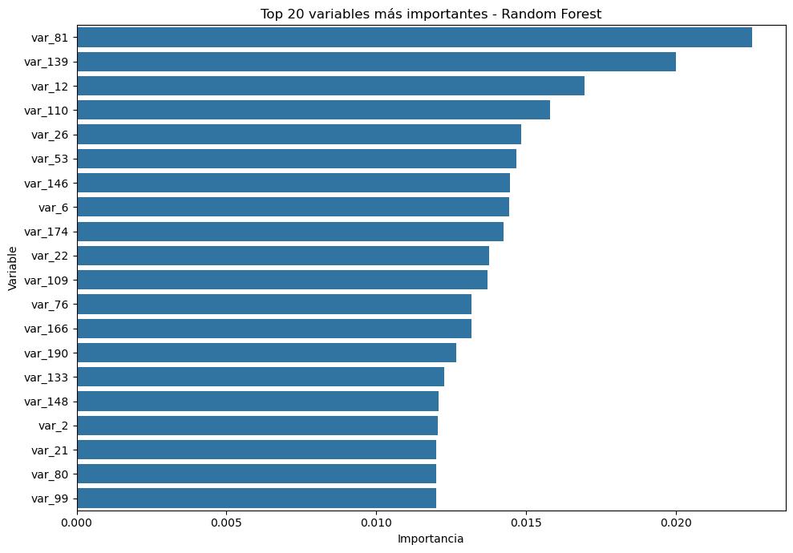

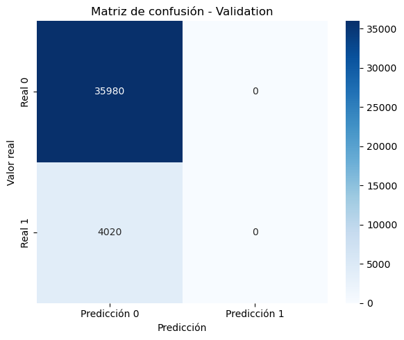

```python
feature_importance = pd.DataFrame({
    "feature": X_train.columns,
    "importance": modelo.feature_importances_
}).sort_values("importance", ascending=False)

print("Top 20 variables más importantes:")
display(feature_importance.head(20))

plt.figure(figsize=(10, 7))

sns.barplot(
    data=feature_importance.head(20),
    x="importance",
    y="feature"
)

plt.title("Top 20 variables más importantes - Random Forest")
plt.xlabel("Importancia")
plt.ylabel("Variable")
plt.tight_layout()
plt.show()

#Matriz de confusión

plt.figure(figsize=(6, 5))

sns.heatmap(
    cm,
    annot=True,
    fmt="d",
    cmap="Blues",
    xticklabels=["Predicción 0", "Predicción 1"],
    yticklabels=["Real 0", "Real 1"]
)

plt.title("Matriz de confusión - Validation")
plt.xlabel("Predicción")
plt.ylabel("Valor real")
plt.tight_layout()
plt.show()
```

## 7. Selección del mejor modelo

- Comparar distintos modelos en función de sus métricas y complejidad.
- Considerar criterios como precisión, interpretabilidad, tiempo de entrenamiento y escalabilidad

```python
resultados_modelos = pd.DataFrame({
    "Modelo": [
        "Random Forest - 200 variables",
        "Random Forest - 200 variables + log",
        "Random Forest - 181 variables",
        "Random Forest - 100 variables",
        "Random Forest - 50 variables"
    ],
    "ROC_AUC_Train": [
        1.0000,
        1.0000,
        1.0000,
        1.0000,
        1.0000
    ],
    "ROC_AUC_Validation": [
        0.8486,
        0.8484,
        0.8517,
        0.8482,
        0.8239
    ],
    "Brecha_Train_Validation": [
        0.1514,
        0.1516,
        0.1483,
        0.1518,
        0.1761
    ]
})

display(resultados_modelos)
```

|  | Modelo | ROC_AUC_Train | ROC_AUC_Validation | Brecha_Train_Validation |
| --- | --- | --- | --- | --- |
| 0 | Random Forest - 200 variables | 1.0 | 0.8486 | 0.1514 |
| 1 | Random Forest - 200 variables + log | 1.0 | 0.8484 | 0.1516 |
| 2 | Random Forest - 181 variables | 1.0 | 0.8517 | 0.1483 |
| 3 | Random Forest - 100 variables | 1.0 | 0.8482 | 0.1518 |
| 4 | Random Forest - 50 variables | 1.0 | 0.8239 | 0.1761 |

Tomando en cuenta los datos anteriores todos los modelos presentan overfitting, sin embargo, el que cuenta con un mayor valor de ROC-AUC en validation y menor brecha es RandomForest con 181 variables, por lo que es el modelo que consideramos vale la pena ajustar y refinar.